# Module 4

Sankalp Biswal

2023-12-02

## 1.Importing Libraries

```r
library(MASS)
library(tidyverse)
library(janitor)
library(knitr)
library(car)
```

## 2. Importing Dataset

```r
dataset <- cats
male <- subset(cats, subset = (cats$Sex=="M"))$Bwt
female <- subset(cats, subset = (cats$Sex=="F"))$Bwt
```

## 3. Testing

## Overview

- There are 2 parts namely - **PART-1 and PART-2**.
- **PART-1** deals with Two sample t-test with unequal variance for **cats** dataset.
- **PART-2** deals with Paired t-test for the provided data for two significance levels, **alpha = 0.05** and **alpha = 0.1**.

### **PART-1**

### Two sample t-test for cats dataset

- We’ll try to answer the question - do male and female cat samples have the same body weight (“Bwt”)?
- First, lets check if the assumptions for a Welch’s t-test are satisfied or not.

#### a. Stating the hypothesis

1. **Null Hypothesis (H0)** - The male and female cats have same body weight.
2. **Alternative Hypothesis (H1)** - The male and female cats don’t have same body weight

#### b. Assumptions of Welch’s t-test.

1. **Independent Samples**: The observations in each group are independent of each other.
2. **Interval or Ratio Data**: The data being compared are measured on an interval.
3. **Approximate Normality**: The sample size is large enough for the model to be robust against this assumption, but we’ll check for normality below.
4. **Unequal Variances**: The variances of the two groups being compared are not necessarily equal.

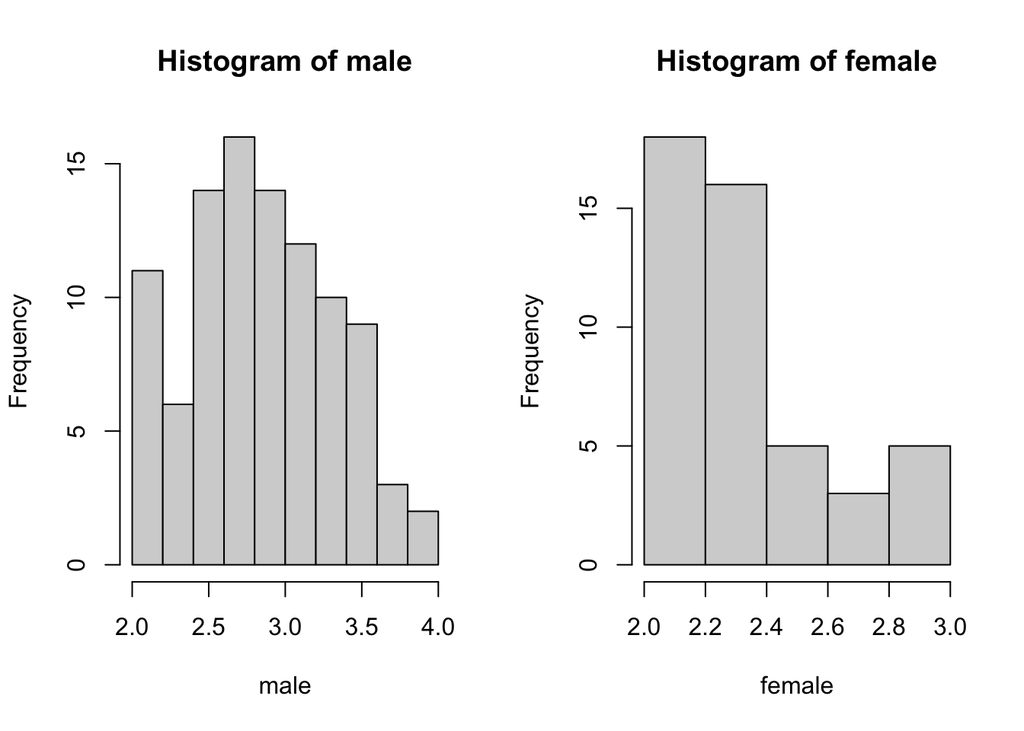

```r
par(mfrow = c(1, 2))

# Plot the first graph
hist(male)
# Plot the second graph
hist(female)
```

```r
par(mfrow = c(1, 1))
```

- Histogram for bodyweight of male cats displays somewhat normal distribution.
- Histogram for bodyweight of female cats displays non-normal distribution.

To confirm the above, we’ll conduct **Shapiro-Wilk normality test**

```r
shapiro.test(male)
```

```
##
##  Shapiro-Wilk normality test
##
## data:  male
## W = 0.97883, p-value = 0.119
```

```r
shapiro.test(female)
```

```
##
##  Shapiro-Wilk normality test
##
## data:  female
## W = 0.89096, p-value = 0.0003754
```

- **Male data:** Since p-value > 0.05(significance level) we can conclude that this is normally distributed.
- **Female data:** Since p-value < 0.05(significance level) we can conclude that this is not normally distributed.

**But since our sample size is > 30, our Welch t-test is robust to such violations**.